# CE2 Mathematics: Probability & Statistics 2018

# Lecture 6 - Chapter 2

## Sections 2.3: Continuous Random Variables - Residence Time Distribution

### To launch the notebook:

- From the menu above, select `Kernel` and `Restart & Run All`.
- Make sure that the `%matplotlib inline` and `%run Codes/Lecture06.ipy` cells were executed without an error. A number will appear to the left of each (e.g. `In [1]`) if successful.
- If you prefer to follow the lecture in slide format, select the Lecture Overview cell and click on the RISE button in the menu above

### Solutions to worked problems during the lecture:

- The answers are encoded by passwords; the information regarding the format of the password can be found by hovering your mouse over the icon
- Type your answer within the quotes in `password''`, then type `Shift` and `Enter` (or click the `>| Run` button above). If you get it correct, the full solution will be displayed. If the answer is incorrect, a random string of text will appear.

```python
%matplotlib inline
```

```python
%run Codes/Lecture06.ipy
```

# Lecture Overview

The lecture today will continue Section 2.3 in Chapter 2 concerning **continuous** random variables, and will particularly focus on **residence time distribution** for chemical reactors. We will use all of the terms below, which we covered in previous lectures:

- 2.3 **Continuous Random Variables**
  - 2.3 **Cumulative Distribution Function, CDF: $F_X(x)=P(X \le x)$**
  - 2.3.1 **Expectation $E[X]$**

# Distribution of Residence Times for Chemical Reactors

- In your studies so far in chemical reaction engineering, you will have developed models based on the assumption that the reactors have perfect mixing (i.e. ideal reactors)
- In practice reactors are not perfectly mixed, so we need capture this behaviour: computing the **Residence Time Distribution** (RTD), represented as $\color{green}{E(t)}$, will be our method for doing so
- Note that $\color{green}{E(t)}$ is a probability density function (PDF), and **NOT** the expectation operation, $E[T] = \int_{-\infty}^{\infty} t \cdot f(t) \; dt$; but we'll use both here...
- This is a topic you will cover in a lecture this term in Reaction Engineering I, and some of you will perform RTD experiments in 2nd Year Knowledge Laboratory.

[figure not shown]

- The experimental approach to determining the residence time distribution (RTD) is conceptually simple: you inject an inert **tracer** into the chemical reactor, and then measure its concentration at the outlet of the reactor to determine the distribution of times that the tracer atoms have spent in the reactor.
- Types of tracers: dyes, salt solutions (Knowledge Labs use KCl), radioactive material

### Two injection methods for experimentally measuring RTD:

- **Pulse response** - forms the basis for a **PDF**: $f(t) \propto \color{blue}{C(t)}$
- **Step response** - forms the basis for a **CDF**: $F(t) \propto \color{blue}{C(t)}$

[figure not shown]

### **1. Pulse Response**:

- For $f(t)$ to be a valid PDF: $$\int_{-\infty}^{\infty} f(t) \; dt = \int_{0}^{\infty} f(t) \; dt = 1$$
- Thus the PDF corresponding to the residence time distribution (denoted as $\color{green}{E(t)}$) is given by: $$\color{green}{E(t)} = f(t) = \frac{\color{blue}{C(t)}}{\color{red}{\int_{0}^{\infty} C(t) \; dt}}$$

### **2. Step Response**:

- Recall our definition of the cumulative distribution function (CDF): $$F(b) = \int_{-\infty}^{b} f(t) \; dt$$
- Thus: \begin{align} F(t=-\infty) =F(t=0)&= 0 \\ F(t=\infty)&= 1 \end{align}
- Applying the latter condition, we find that the residence time distribution $\color{green}{E(t)}$ can be computed from the CDF as: $$\color{green}{E(t)} = f(t) = \frac{dF(t)}{dt} = \frac{d}{dt} \frac{\color{blue}{C(t)}}{\color{red}{C_{0}}}$$
  - where $\color{red}{C_0}$ corresponds to tracer concentration at the step injection.

### Using $E(t)$ to compute mean properties

- Thus the PDF corresponding to the residence time distribution, $f(t) = \color{green}{E(t)}$, can experimentally measured from $\color{blue}{C(t)}$ by either a pulse or step injection experiment
- We can also derive $\color{green}{E(t)}$ for *ideal* chemical reactors using first principles, which we will also do in this lecture
- Once we have $\color{green}{E(t)}$, we can compute important quantities such as the **mean** residence time (denoted as $\overline t$) and **mean** concentration (denoted as $\overline C$) using the **Expectation** operation!
- To compute these mean properties using the expectation, first recall that we defined expectation of a function $g(t)$ of random variable $t$ to be: $$E[g(T)] = \int_{-\infty}^{\infty} g(t) \; f(t)\; dt$$
- Noting that the PDF is $f(t)=\color{green}{E(t)}$ for random variable $t$ we have: \begin{align} \overline t &= E[T] = \cdots \\ \overline C &= E[C(T)] = \cdots \end{align}

```python
display_answer(question=0, password='t,C(t)')
```

## Ideal CSTR

- **Ideal Mixing**: what would $\color{green}{E(t)}$ be for an ideal CSTR?
- A **pulse** tracer of concentration $C_0$ is added at time $t=0$. Assuming perfect mixing (concentration $\color{blue}{C(t)}$ at the outlet is equal to that within the reactor), the material balance around the CSTR for $t > 0$ is: $$\text{in + generation - out = accumulation} $$

```python
display_answer(question=1, password='C0e^(-t/tau)')
```

\begin{align} 0 &+ 0 -vC = V_R \frac{dC}{dt} \\ \frac{dC}{dt} &= \frac{-v}{V_R} C = - \frac{1}{\tau} C \\ \int_{C_0}^C \frac{dC}{C} &= - \frac{1}{\tau} \int_0^t \; dt \implies C(t) = C_0 \exp{\left(\frac{-t}{\tau}\right)} \\ \text{where tau is the "space time" or "holding time"} \end{align}

- **Ideal Mixing**: what would $\color{green}{E(t)}$ be for an ideal CSTR?
- For a pulse response, we defined the residence time distribution as: $$\color{green}{E(t)} = \frac{\color{blue}{C(t)}}{\color{red}{\int_{0}^{\infty} C(t) \; dt}} = \cdots$$
- And so the mean residence time, for instance, is computed as: $$\overline t = E[T] = \cdots$$

```python
display_answer(question=2, password='space time')
```

\begin{align} \color{green}{E(t)} = \frac{\color{blue}{C(t)}}{\color{red}{\int_{0}^{\infty} C(t) \; dt}} &= \frac{C_0 \exp{\left(\frac{-t}{\tau}\right)}}{C_0 \int_0^\infty \exp{\left(\frac{-t}{\tau}\right)} \; dt} = \frac{\exp{\left(\frac{-t}{\tau}\right)}}{-\tau \left[ \exp{\left(\frac{-t}{\tau}\right)} \right]_0^\infty} = \frac{\exp{\left(\frac{-t}{\tau}\right)}}{\tau} \\ \overline t = E[T] &= \int_0^\infty t \cdot \frac{\exp{\left(\frac{-t}{\tau}\right)}}{\tau} \; dt \\ & \qquad \int u \; dv = uv - \int v \; du \\ & \qquad u = t \to du = 1 \\ & \qquad dv= \frac{\exp{\left(\frac{-t}{\tau}\right)}}{\tau} \to v = - \exp{\left(\frac{-t}{\tau}\right)} \\ &= \left[ -t \cdot \exp{\left(\frac{-t}{\tau}\right)} \right]_0^\infty + \int_0^\infty \exp{\left(\frac{-t}{\tau}\right)} \\ &= -\tau \left[ \exp{\left(\frac{-t}{\tau}\right)} \right]_0^\infty = \tau = \frac{V_R}{v} \end{align}

## Non-Ideal CSTR: Lab Data

- Consider a step-injection RTD experiment for a CSTR recently installed in the UG labs. The concentration of the KCl tracer is $\color{red}{C_{0}} = 0.055$ M.
- The total volume of the CSTR reactor is $V_R=2.4$ L, filled to a level of 80%, with a flow rate of $v=1$ L/min.
- The **step response** of KCl concentration ($\color{blue}{C(t)}$) is measured using a conductivity meter.
- What is the corresponding space time?

```python
display_answer(question=3, password='115.20')
```

$$\tau = \frac{V_R}{v} = \frac{2.4 \text{ L} \times 0.8}{1 \text{ L/min}} \times \frac{60 \text{ s}}{\text{min}} = 115.20 \text{s}$$

### Code for CSTR RTD

```python
### CSTR PARAMETERS (and units)
C0 = 0.055;       # M
V_R = 2.4;        # L
Level = 0.8;      # 80%
flowrate = 1/60;  # L/s

V_R_corrected = V_R*Level;
```

```python
### Read in CSV file containing CSTR data from UG Labs
data = pd.read_csv('Data/RTD_CSTR_Data.csv')

### Print out data (optional; comment using # to suppress the print)
data
```

|  | Time(s) | Conc(M) |
| --- | --- | --- |
| 0 | 0.2 | 0.000012 |
| 1 | 0.4 | 0.000012 |
| 2 | 0.6 | 0.000012 |
| 3 | 0.8 | 0.000012 |
| 4 | 1.0 | 0.000012 |
| 5 | 1.2 | 0.000040 |
| 6 | 1.4 | 0.000086 |
| 7 | 1.6 | 0.000133 |
| 8 | 1.8 | 0.000180 |
| 9 | 2.0 | 0.000234 |
| 10 | 2.2 | 0.000277 |
| 11 | 2.4 | 0.000323 |
| 12 | 2.6 | 0.000477 |
| 13 | 2.8 | 0.000685 |
| 14 | 3.0 | 0.000872 |
| 15 | 3.2 | 0.001053 |
| 16 | 3.4 | 0.001166 |
| 17 | 3.6 | 0.001166 |
| 18 | 3.8 | 0.001166 |
| 19 | 4.0 | 0.001166 |
| 20 | 4.2 | 0.001220 |
| 21 | 4.4 | 0.001310 |
| 22 | 4.6 | 0.001401 |
| 23 | 4.8 | 0.001880 |
| 24 | 5.0 | 0.002572 |
| 25 | 5.2 | 0.003219 |
| 26 | 5.4 | 0.003856 |
| 27 | 5.6 | 0.004245 |
| 28 | 5.8 | 0.004245 |
| 29 | 6.0 | 0.004245 |
| ... | ... | ... |
| 996 | 199.4 | 0.055400 |
| 997 | 199.6 | 0.055446 |
| 998 | 199.8 | 0.055493 |
| 999 | 200.0 | 0.055540 |
| 1000 | 200.2 | 0.055568 |
| 1001 | 200.4 | 0.055568 |
| 1002 | 200.6 | 0.055568 |
| 1003 | 200.8 | 0.055568 |
| 1004 | 201.0 | 0.055568 |
| 1005 | 201.2 | 0.055568 |
| 1006 | 201.4 | 0.055540 |
| 1007 | 201.6 | 0.055493 |
| 1008 | 201.8 | 0.055446 |
| 1009 | 202.0 | 0.055400 |
| 1010 | 202.2 | 0.055400 |
| 1011 | 202.4 | 0.055446 |
| 1012 | 202.6 | 0.055493 |
| 1013 | 202.8 | 0.055567 |
| 1014 | 203.0 | 0.055637 |
| 1015 | 203.2 | 0.055683 |
| 1016 | 203.4 | 0.055726 |
| 1017 | 203.6 | 0.055726 |
| 1018 | 203.8 | 0.055683 |
| 1019 | 204.0 | 0.055637 |
| 1020 | 204.2 | 0.055595 |
| 1021 | 204.4 | 0.055568 |
| 1022 | 204.6 | 0.055568 |
| 1023 | 204.8 | 0.055540 |
| 1024 | 205.0 | 0.055493 |
| 1025 | 205.2 | 0.055446 |

1026 rows × 2 columns

- Step response $\color{blue}{C(t)}$ measured for $\color{red}{C_{0}} = 0.055$ M for a CSTR.

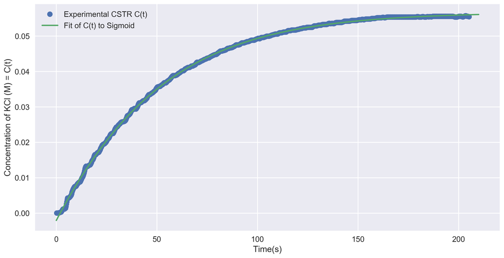

```python
### Fit the data with a sigmoid curve
popt, _ = curve_fit(sigmoid, data['Time(s)'], data['Conc(M)'], maxfev=4000)

### Plot the raw lab data points
plt.plot(data['Time(s)'],data['Conc(M)'],'o',label='Experimental CSTR C(t)')

### Vector of 500 time points in the interval [0,210]
t = np.linspace(0, 210, 500)
### Plot the fitted sigmoid curve over the time interval
plt.plot(t, sigmoid(t, *popt), label='Fit of C(t) to Sigmoid')

### Axes labels, legend
plt.xlabel('Time(s)'); plt.ylabel('Concentration of KCl (M) = C(t)'); plt.legend();
```

- Where we have fit the data to the following sigmoid function (in notebook.py): $$C(t) = \frac{a}{1 + \exp^{-k*(t-t_0)}} + c$$

```python
### Values for the sigmoid parameters for the CSTR data
print("t0 =", popt[0])
print("k  =", popt[1])
print("a  =", popt[2])
print("c  =", popt[3])
```

```
t0 = -69.3417645014
k  = 0.0224258935073
a  = 0.337210421774
c  = -0.280486294801
```

### Computing $\color{green}{E(t)}$ from the measured $\color{blue}{C(t)}$ data for a CSTR.

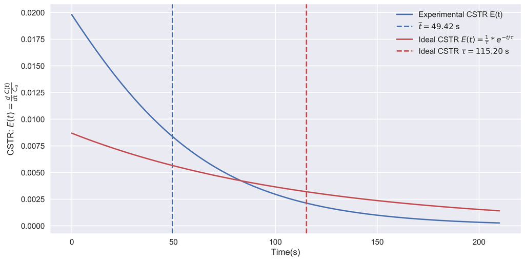

```python
### Space time
Tau = V_R_corrected/flowrate

### Plot the residence time distribution E(t) for the CSTR data
plt.plot(t, dCdt(t, *popt)/C0, label='Experimental CSTR E(t)',color='b')

## Compute E[T] to get the mean residence time (note dCdt is implemented in notebook.py)
mean_t = np.trapz(t*dCdt(t, *popt)/C0, t);

## Mark where E[T] is in the plot
plt.axvline(mean_t, linestyle='--', label=r'$\overline{{t}}={:.2f}$ s'.format(mean_t), color='b')

### Plot the residence time distribution E(t) for an ideal CSTR (solved above and implemented in notebook.py)
plt.plot(t, E_CSTR_ideal(t, Tau), label=r'Ideal CSTR $E(t)=\frac{1}{\tau}*e^{-t/\tau}$',color='r')
## Mark where E[T] for an ideal CSTR is in the plot
plt.axvline(Tau, linestyle='--', label=r'Ideal CSTR $\tau={:.2f}$ s'.format(Tau), color='r')

### Axes labels, legend
plt.xlabel('Time(s)'); plt.ylabel(r'CSTR: $E(t)=\frac{d}{dt}\frac{C(t)}{C_0}$'); plt.legend();
```

- Based on these results, where is the majority of our non-ideality stemming from?

[figure not shown]

# PFR: RTD Data

- Next consider another RTD experiment from UG labs, where a step-injection of 0.1M KCl ($\color{red}{C_{0}} = 0.1$ M) is performed using a $V_R=0.4$ L PFR.
- The **step response** of KCl concentration ($\color{blue}{C(t)}$) is measured using a conductivity meter.
- Can collect data for different peristaltic pump speeds. Let's consider data where pump speed = 6 (corresponding flow rate experimentally estimated to be $v=1.284$ mL/s).
- What is the corresponding space time?

```python
display_answer(question=4, password='311.53')
```

$$\tau = \frac{V_R}{v} = \frac{0.4 \text{ L}}{1.284 \text{ mL/s}} \times \frac{1000 \text{ mL}}{\text{L}} = 311.53 \text{s}$$

### Code for PFR RTD

```python
### PFR PARAMETERS (and units)
C0 = 0.1;         # M
V_R = 0.4;        # L
Level = 1.0;      # 100%
flowrate = (1.284)/1000;  # L/s

V_R_corrected = V_R*Level;
```

```python
### Read in CSV file containing PFR data from UG Labs
data = pd.read_csv('Data/RTD_PFR_Data.csv')

### Print out data (optional; comment using # to suppress the print)
data
```

|  | Time(s) | Conc(M) |
| --- | --- | --- |
| 0 | 0.0 | 0.000096 |
| 1 | 5.0 | 0.000159 |
| 2 | 10.0 | 0.000255 |
| 3 | 15.0 | 0.000319 |
| 4 | 20.0 | 0.000446 |
| 5 | 25.0 | 0.000598 |
| 6 | 30.0 | 0.000702 |
| 7 | 35.0 | 0.000901 |
| 8 | 40.0 | 0.001148 |
| 9 | 45.0 | 0.001451 |
| 10 | 50.0 | 0.001706 |
| 11 | 55.0 | 0.001977 |
| 12 | 60.0 | 0.002272 |
| 13 | 65.0 | 0.002607 |
| 14 | 70.0 | 0.002989 |
| 15 | 75.0 | 0.003396 |
| 16 | 80.0 | 0.003866 |
| 17 | 85.0 | 0.004393 |
| 18 | 90.0 | 0.004959 |
| 19 | 95.0 | 0.005636 |
| 20 | 100.0 | 0.006378 |
| 21 | 105.0 | 0.007215 |
| 22 | 110.0 | 0.008147 |
| 23 | 115.0 | 0.009176 |
| 24 | 120.0 | 0.010188 |
| 25 | 125.0 | 0.011392 |
| 26 | 130.0 | 0.012867 |
| 27 | 135.0 | 0.015210 |
| 28 | 140.0 | 0.019129 |
| 29 | 145.0 | 0.021088 |
| ... | ... | ... |
| 67 | 335.0 | 0.089923 |
| 68 | 340.0 | 0.090482 |
| 69 | 345.0 | 0.091040 |
| 70 | 350.0 | 0.091518 |
| 71 | 355.0 | 0.091996 |
| 72 | 360.0 | 0.092395 |
| 73 | 365.0 | 0.092793 |
| 74 | 370.0 | 0.093192 |
| 75 | 375.0 | 0.093511 |
| 76 | 380.0 | 0.093909 |
| 77 | 385.0 | 0.094149 |
| 78 | 390.0 | 0.094467 |
| 79 | 395.0 | 0.094707 |
| 80 | 400.0 | 0.094866 |
| 81 | 405.0 | 0.095105 |
| 82 | 410.0 | 0.095344 |
| 83 | 415.0 | 0.095504 |
| 84 | 420.0 | 0.095663 |
| 85 | 425.0 | 0.095823 |
| 86 | 430.0 | 0.095982 |
| 87 | 435.0 | 0.096142 |
| 88 | 440.0 | 0.096301 |
| 89 | 445.0 | 0.096381 |
| 90 | 450.0 | 0.096540 |
| 91 | 455.0 | 0.096620 |
| 92 | 460.0 | 0.096700 |
| 93 | 465.0 | 0.096859 |
| 94 | 470.0 | 0.096939 |
| 95 | 475.0 | 0.097018 |
| 96 | 480.0 | 0.097018 |

97 rows × 2 columns

### Step response $\color{blue}{C(t)}$ measured for $\color{red}{C_{0}} = 0.1$ M for a PFR.

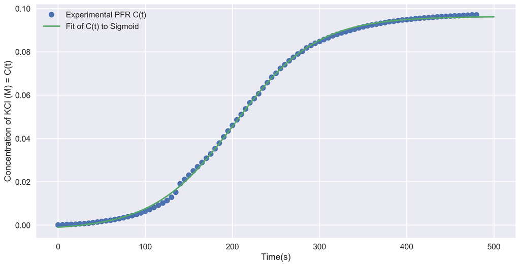

```python
### Vector of 500 time points in the interval [0,500]
t = np.linspace(0, 500, 500)

### Fit the data with a sigmoid curve
popt, _ = curve_fit(sigmoid, data['Time(s)'], data['Conc(M)'], maxfev=4000)

### Plot the raw lab data points
plt.plot(data['Time(s)'],data['Conc(M)'],'o',label='Experimental PFR C(t)')

### Plot the fitted sigmoid curve
plt.plot(t, sigmoid(t, *popt), label='Fit of C(t) to Sigmoid')

### Plot the fitted sigmoid curve
plt.xlabel('Time(s)'); plt.ylabel('Concentration of KCl (M) = C(t)'); plt.legend();
```

- Where we have fit the data to the following sigmoid function (in notebook.py): $$C(t) = \frac{a}{1 + \exp^{-k*(t-t_0)}} + c$$

```python
### Values for the sigmoid parameters for the PFR data
print("t0 =", popt[0])
print("k  =", popt[1])
print("a  =", popt[2])
print("c  =", popt[3])
```

```
t0 = 202.805600697
k  = 0.0213983644588
a  = 0.0985794094338
c  = -0.002266078737
```

### Computing $\color{green}{E(t)}$ from the measured $\color{blue}{C(t)}$ data for a PFR.

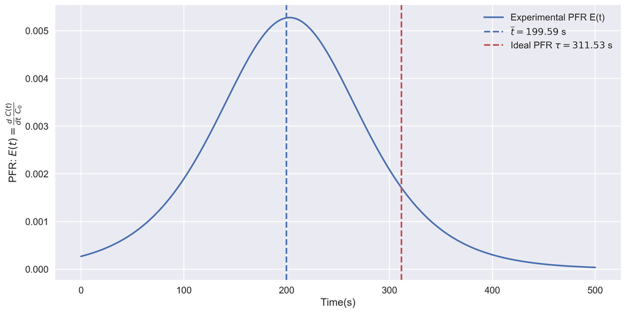

```python
### Space time
Tau = V_R_corrected/flowrate

### Plot the residence time distribution E(t) for the PFR data (note dCdt is implemented in notebook.py)
plt.plot(t, dCdt(t, *popt)/C0, label='Experimental PFR E(t)',color='b')

## Compute E[T] to get the mean residence time (note dCdt is implemented in notebook.py)
mean_t = np.trapz(t*dCdt(t, *popt)/C0, t);

## Mark where E[T] is in the plot
plt.axvline(mean_t, linestyle='--', label=r'$\overline{{t}}={:.2f}$ s'.format(mean_t), color='b')

## Mark where E[T] for an ideal PFR is in the plot
plt.axvline(Tau, linestyle='--', label=r'Ideal PFR $\tau={:.2f}$ s'.format(Tau), color='r')

### Axes labels, legend
plt.xlabel('Time(s)'); plt.ylabel(r'PFR: $E(t)=\frac{d}{dt}\frac{C(t)}{C_0}$'); plt.legend();
```

- What is $\color{green}{E(t)}$ for an ideal PFR?
- Based on these results, where is the majority of our non-ideality stemming from?

[figure not shown]

## Summary

This lecture continued our examples of continuous random variables (section 2.3), and introduced the concept of the **residence time distribution** (used in Knowledge Labs and RE-I):

- The Residence Time Distribution, $\color{green}{E(t)}$, is a probability density function (PDF)
- **1. Pulse Response**: $\color{green}{E(t)}$ is computed by normalising $\color{blue}{C(t)}$: $$\color{green}{E(t)} = f(t) = \frac{\color{blue}{C(t)}}{\color{red}{\int_{0}^{\infty} C(t) \; dt}}$$
- **2. Step Response**: $\color{green}{E(t)}$ is computed as the derivative of $\color{blue}{C(t)}$ normalised by the magnitude of the step injection $\color{red}{C_{0}}$: $$\color{green}{E(t)} = f(t) = \frac{dF(t)}{dt} = \frac{d}{dt} \frac{\color{blue}{C(t)}}{\color{red}{C_{0}}}$$
- Use expectation operation $E[g(T)]$ to get mean property values (e.g. residence time, concentration)